# Math 421 - Midterm

## II. Data Visualization

Continue with the data from part I.

1. Provides at least 10 meaningful plots. Comments on the plots. All plots should have title, caption, appropriate labels on x and y-axis

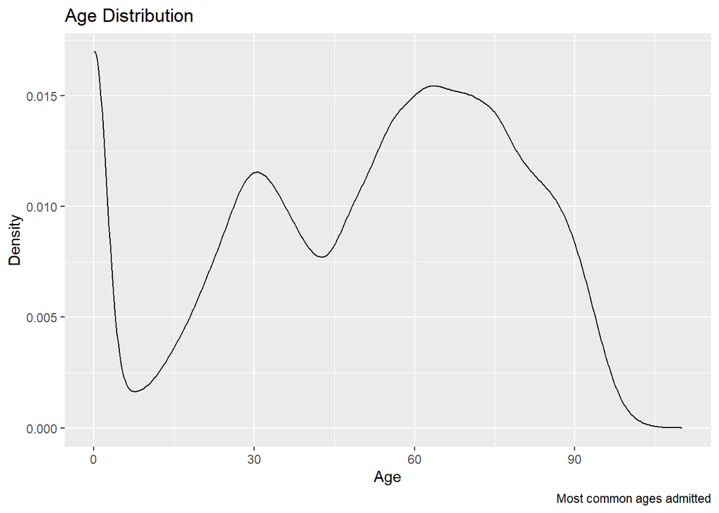

```r
library(ggplot2)

df %>% ggplot()+
  geom_density(mapping = aes(x = age)) +
  labs(x="Age", y="Density", title = "Age Distribution", caption="Most common ages admitted")
```

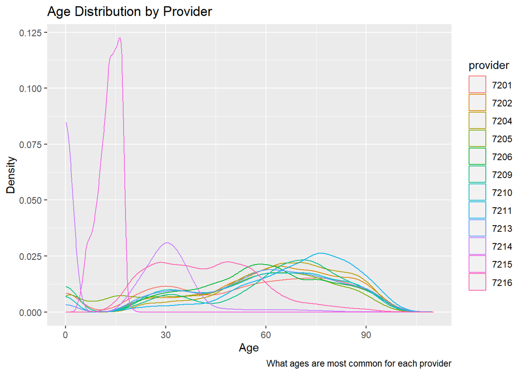

```r
##It is more common that people in their 60s are admitted##

df %>% ggplot()+
  geom_density(mapping = aes(x = age, color=provider))+
  labs(x="Age", y="Density", title = "Age Distribution by Provider", caption="What ages are most common for each provider")
```

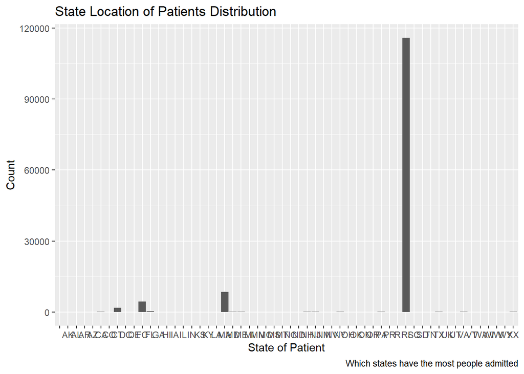

```r
##Bradley admits the youngest population among the providers##

df %>% ggplot()+
  geom_bar(mapping = aes(x = pt_state))+
  labs(x="State of Patient", y="Count", title = "State Location of Patients Distribution", caption="Which states have the most people admitted")
```

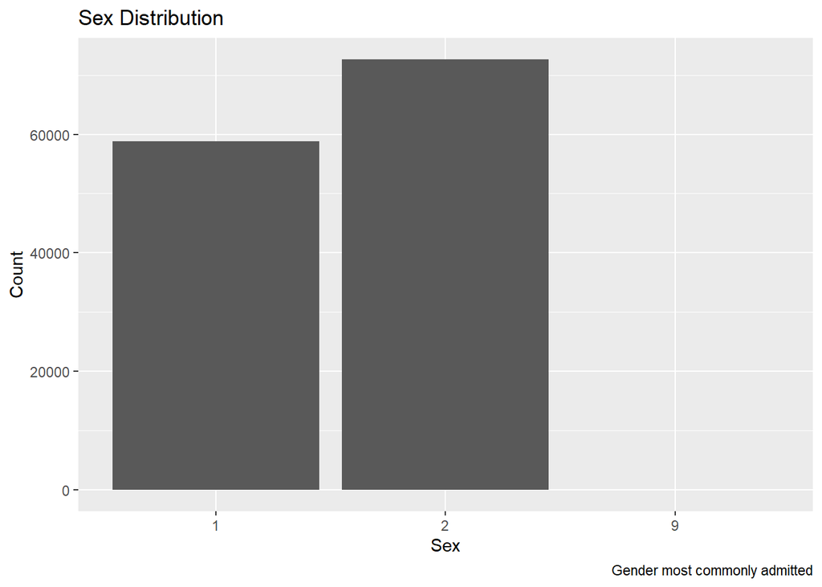

```r
##Rhode Island is the most common state with Massachusetts in second with two other states showing data##

df %>% ggplot()+
  geom_bar(mapping = aes(x = sex))+
  labs(x="Sex", y="Count", title = "Sex Distribution", caption="Gender most commonly admitted")
```

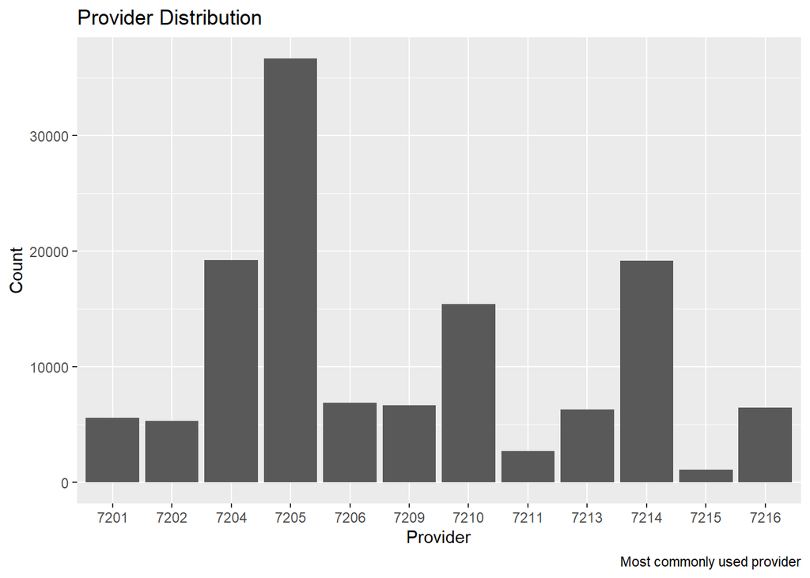

```r
##Female is the most common admitted##

df %>% ggplot()+
  geom_bar(mapping = aes(x = provider))+
  labs(x="Provider", y="Count", title = "Provider Distribution", caption="Most commonly used provider")
```

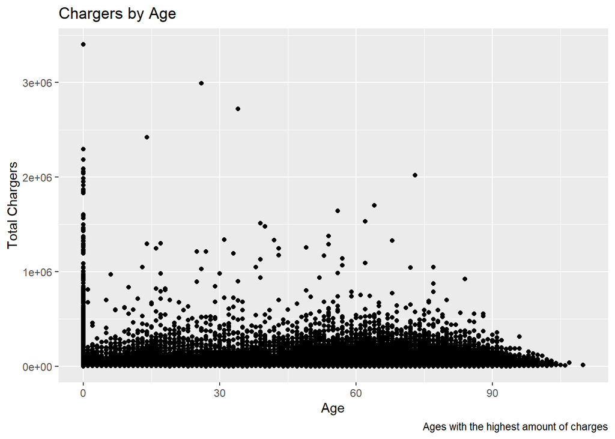

```r
##The most commonly used provider is Rhode Island Hospital##

df %>% ggplot()+geom_point(aes(x=age, y=tot))+
  labs(x="Age", y="Total Chargers", title = "Chargers by Age", caption="Ages with the highest amount of charges")
```

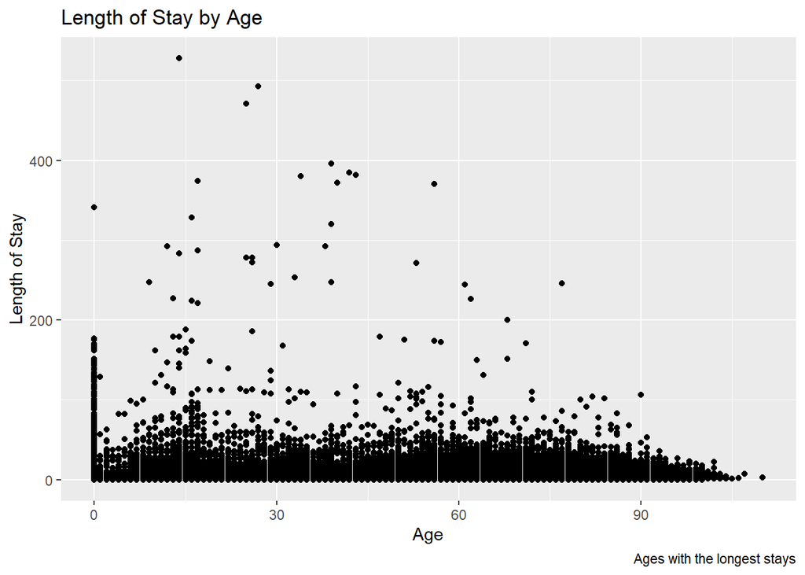

```r
##Younger people tend to have more extreme charges##

df %>% ggplot()+geom_point(aes(x=age, y=los))+
  labs(x="Age", y="Length of Stay", title = "Length of Stay by Age", caption="Ages with the longest stays")
```

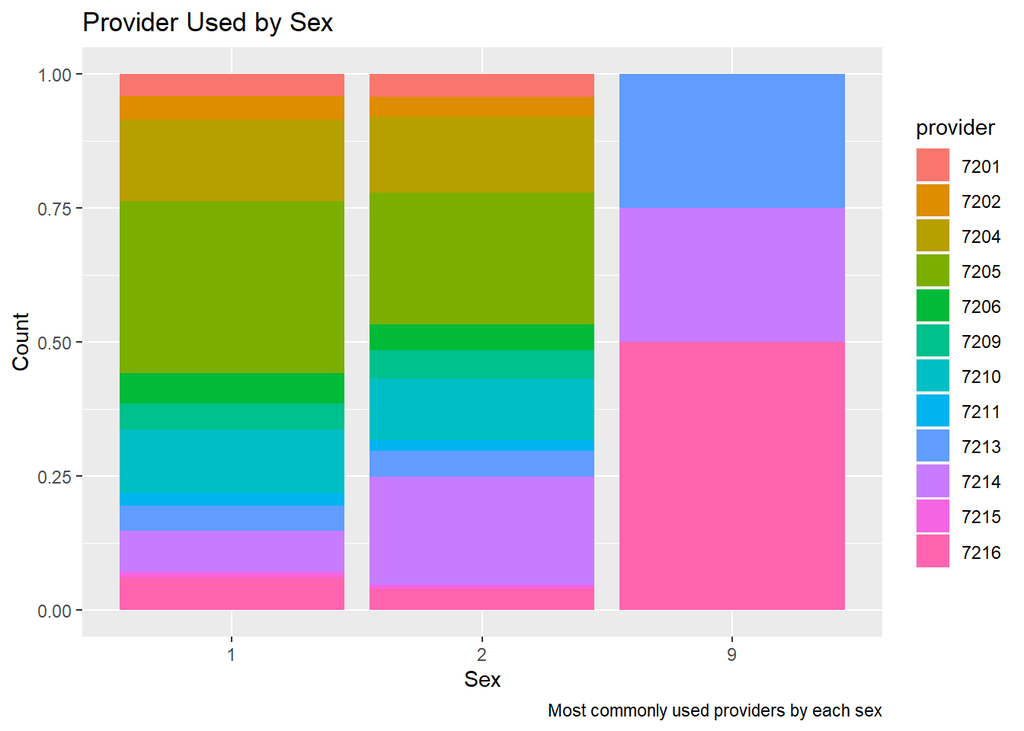

```r
##Length of stay is typically longer for people around the age 30##

df %>% ggplot()+
  geom_bar(mapping=aes(x=sex, fill=provider), position = 'fill')+
  labs(x="Sex", y="Count", title = "Provider Used by Sex", caption="Most commonly used providers by each sex")
```

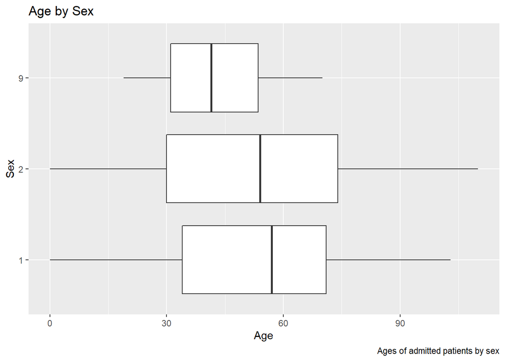

```r
##This shows the most common providers among each gender##

df %>% ggplot()+
  geom_boxplot(mapping = aes(x = age, y = sex))+
  labs(x="Age", y="Sex", title = "Age by Sex", caption="Ages of admitted patients by sex")
```

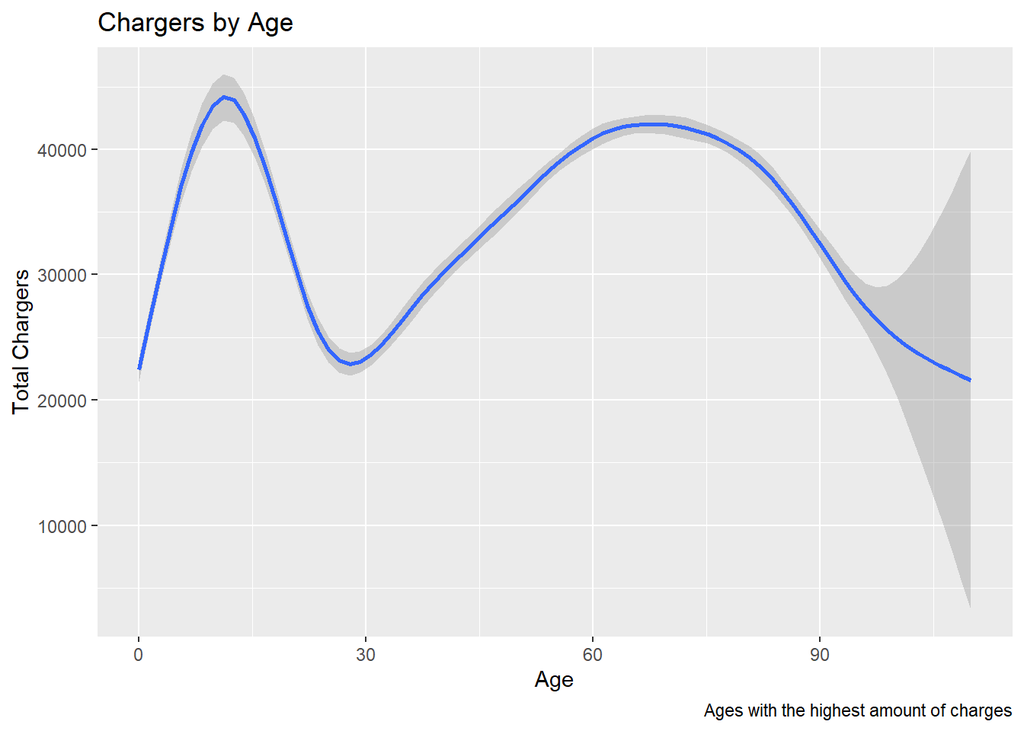

```r
##This plot shows the distribution of ages for males and females##

df %>% ggplot()+geom_smooth(aes(x=age, y=tot))+
  labs(x="Age", y="Total Chargers", title = "Chargers by Age", caption="Ages with the highest amount of charges")
```

```r
##There's a greater spread as people get older##
```

2. Make an animation plot.

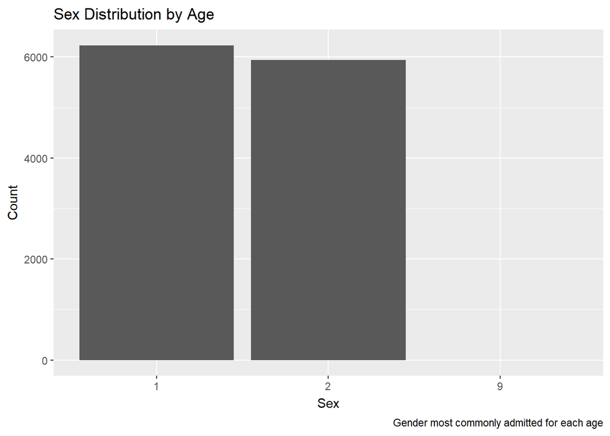

```r
library(gganimate)
df %>% ggplot()+
  geom_bar(mapping = aes(x = sex)) + transition_states(age) +
  labs(x="Sex", y="Count", title = "Sex Distribution by Age", caption="Gender most commonly admitted for each age")
```

3. Write a paragraph to summarize the section and give your comments on the results.

```r
##In this section, I created different graphs such as bar plots, scatter plots, box plots, etc. to represent information on the data.  I also created animations and labels for the graphs.  Some of the important information the graphs tell us are the most common age of admittance is people in their 60s, females are most commonly admitted with Rhode Island hospital admitting the most people, but Bradley admits the youngest people.##
```

## III. Predictive Models

Continue with the data from part I. Make sure you do not have any missing values in the data. Use the follows as the target and input variables:

*Target Variable*: Create the target variable taking value of

- `low` if the total charge of a patient (`tot`) is smaller than the median of the total charge, and
- `high` otherwise.

*Input Variables*:

```r
library(caret)
df <- read_csv('midterm_csv')
df <- df %>% filter(raceethn!='', admtype!='')
df$tot2 <- ifelse(df$tot<median(df$tot),'low', 'high')
df <- df %>%
  mutate(target = as.factor(tot2),
         sex = as.factor(sex),
         raceehtn = as.factor(raceethn),
         campus = as.factor(campus),
         moa = as.factor(moa),
         mod = as.factor(mod),
         admtype=as.factor(admtype))
df <- df %>%
  mutate(age = as.numeric(age),
         los = as.numeric(los))
df <- df %>% select(target,age,sex,raceethn,provider,moa,mod,admtype,campus,los)
set.seed(2020)
splitIndex <- createDataPartition(df$target, p = .90, list=FALSE)
df_train <- df[ splitIndex,]
df_test <- df[-splitIndex,]
```

2. Train a decision tree using `rpart`. Plot the decision tree. Plot the variable importance ranked by the tree.

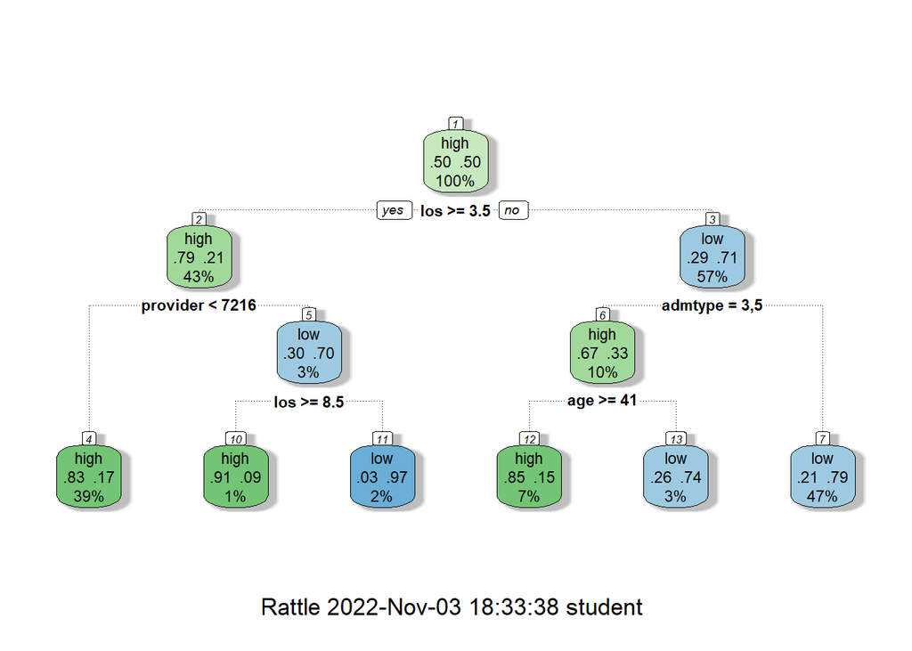

```r
library(rpart)
tree_model <- rpart(target ~ ., data = df_train,
                 control = rpart.control(maxdepth = 3))
library(rattle)
fancyRpartPlot(tree_model)
```

```r
tree_model$variable.importance
```

```
##          los      admtype     provider          age       campus     raceethn
## 1.520880e+04 4.264411e+03 3.105460e+03 1.909396e+03 7.752431e+02 1.331741e+02
##          sex
## 2.858678e-01
```

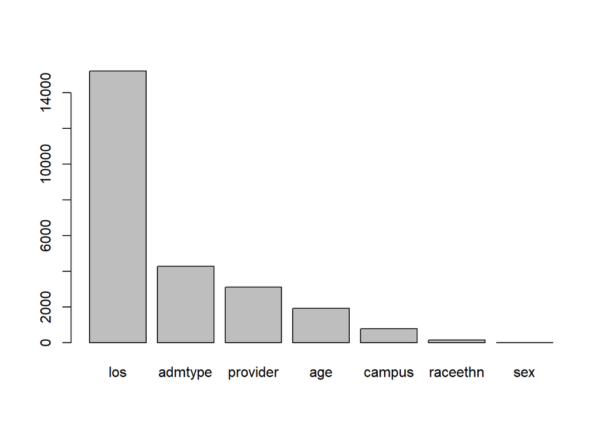

```r
barplot(tree_model$variable.importance)
```

3. Using caret for this question. Set `Training Control` to be: Use Cross-Validation of 5 folds across all models. Train & tune at least 2 different models (i.e. two different values for `method=` in the train function of caret). Plot the hyper-parameter tuning plots for each model.

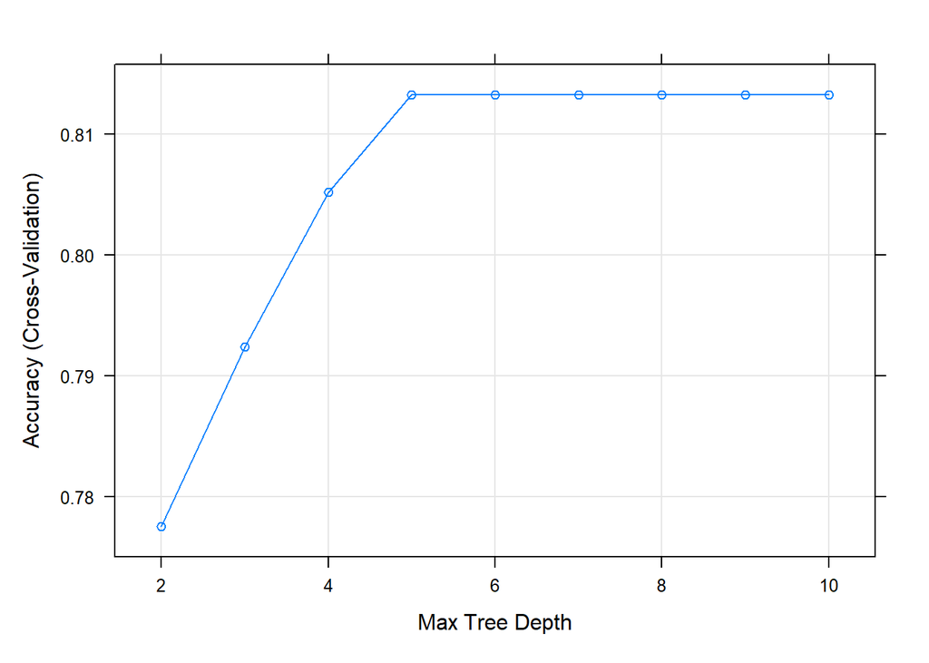

```r
tuneGrid = expand.grid(maxdepth = 2:10)
trControl = trainControl(method = "cv",
                         number = 5)
tree_approach2 <- train(target~., data=df_train,
                  method = "rpart2", trControl                        =trControl, tuneGrid = tuneGrid)
plot(tree_approach2)
```

```r
trControl1 = trainControl(method = "cv",
                         number = 5)
tuneGrid1 = expand.grid(mtry = 2:4,
          splitrule = c('gini', 'extratrees'),
           min.node.size = c(2:5))
forest_ranger <- train(target~., data=df_train,
                    method = "ranger",
                    trControl = trControl1,
                    tuneGrid = tuneGrid1)
```

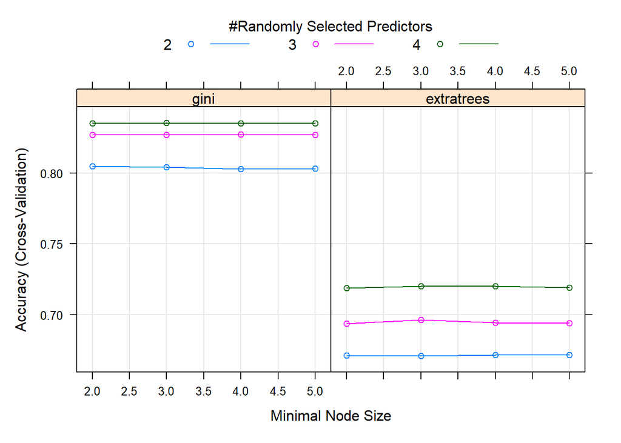

```r
plot(forest_ranger)
```

4. Plot the comparison of the models in 3.

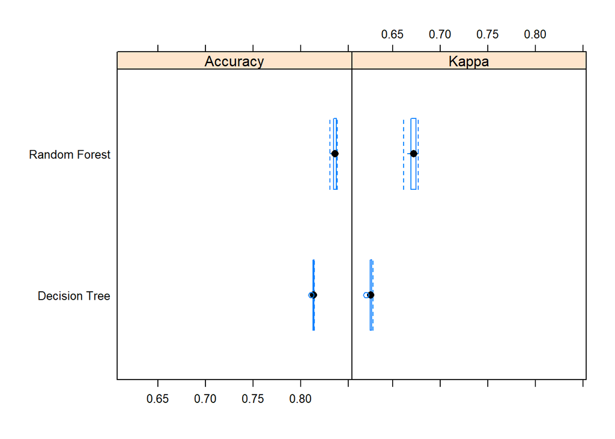

```r
results <- resamples(list('Decision Tree' = tree_approach2,'Random Forest' = forest_ranger))

bwplot(results)
```

5. What is your final selection for the model? Test the accuracy of your final model on the test data.

```r
##Final selection for the model is the tree model##
pred1 <- predict(tree_approach2, df_test)
cm1 <- confusionMatrix(data = pred1, reference = df_test$target)
cm1$overall[1]
```

```
## Accuracy
## 0.813441
```

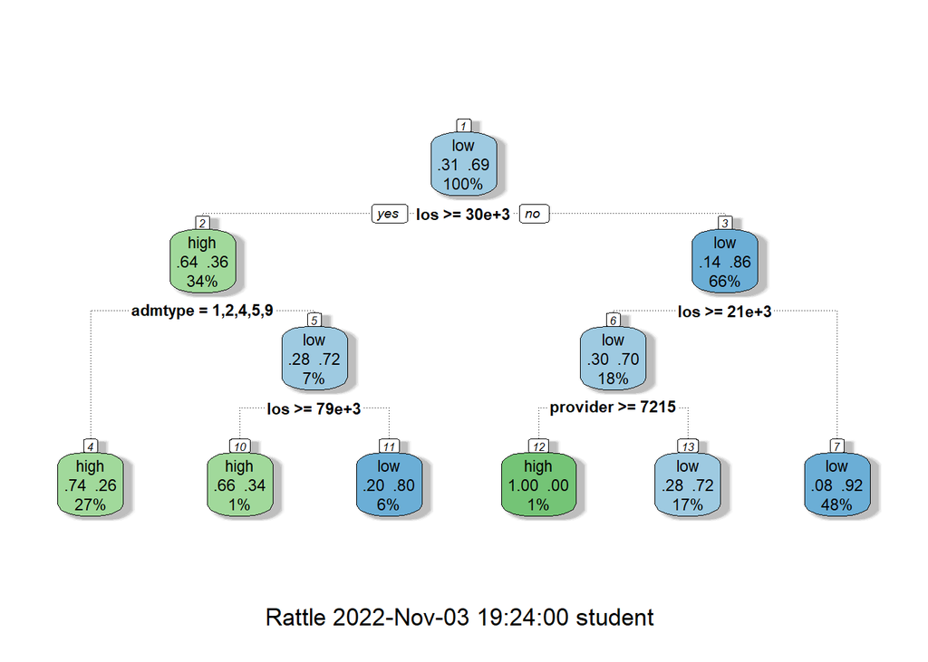

```r
df <- read_csv('midterm_csv')
df <- df %>% filter(raceethn!='', admtype!='')
df$los2 <- ifelse(df$los<mean(df$los),'low', 'high')
df <- df %>%
  mutate(target = as.factor(los2),
         sex = as.factor(sex),
         raceehtn = as.factor(raceethn),
         campus = as.factor(campus),
         moa = as.factor(moa),
         mod = as.factor(mod),
         admtype=as.factor(admtype))
df <- df %>%
  mutate(age = as.numeric(age),
         los = as.numeric(tot))
df <- df %>% select(target,age,sex,raceethn,provider,moa,mod,admtype,campus,los)
set.seed(2020)
splitIndex <- createDataPartition(df$target, p = .90, list=FALSE)
df_train <- df[ splitIndex,]
df_test <- df[-splitIndex,]

tree_model1 <- rpart(target ~ ., data = df_train,
                 control = rpart.control(maxdepth = 3))
fancyRpartPlot(tree_model1)
```

```r
tree_model1$variable.importance
```

```
##        los    admtype   provider     campus
## 15267.6263  3061.5522   788.2141   391.5014
```